# Comparing groups

Esko

29.06.2016

The next topic is about comparing two groups of observations.

## Dataset

We will use a subset of data from an experiment, where a group of children and a group of adults played a learning game.

In the game, the participants watched video clips filmed from bicyclists perspective. Their task was to keep an eye on the other road users. In each video clip, the video was suddenly masked and 2-4 circles were drawn on the masked screen. The players task was to select all those circles, where was a road user at the moment when the video was masked (see Figures below).

[figure not shown]

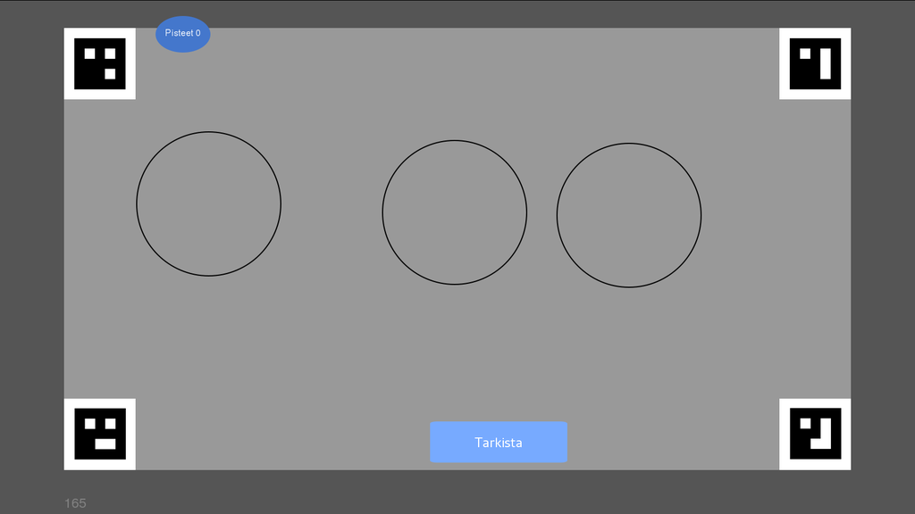

The dataset contains the following variables: - player_id : participant id - age_grp : C = children, A = adult - Phit : the proportion of correctly selected circles - Pmiss : the proportion of circles which should have been selected but were not not - PfalseAlarma: the proportion of circles which were selected but which did not have a road user on their location - PcorrectRejection: the proportion of circles which were correctly left unselected

## Reading and viewing the data

```r
game <- read.table("kr_game.txt", header=TRUE)
head(game)
```

```
##   age_grp  player_id      Phit      Pmiss PfalseAlarm PcorrectRejection
## 1       A 2016020202 0.5189873 0.05063291  0.07594937         0.3544304
## 2       A 2016020302 0.5063291 0.06329114  0.07594937         0.3544304
## 3       A 2016020402 0.4430380 0.12658228  0.06329114         0.3670886
## 4       A 2016020403 0.5063291 0.06329114  0.08860759         0.3417722
## 5       A 2016020404 0.5443038 0.02531646  0.07594937         0.3544304
## 6       A 2016020405 0.5189873 0.05063291  0.18987342         0.2405063
```

## Question: Do adults perform better than children?

An obvious way to characterize the performance is to calculate the accuracy of the responses. Accuracy can be defined as the proportion of hits (correctly selected) and correct rejection (correctly left unselected).

```r
game$accuracy <- game$Phit + game$PcorrectRejection
```

## Boxplot

I prefer to plot the data first, before making any descriptive statistics of statistical tests.

Because the variable of interests accuracy is a continous variable, a boxplot is a very practical way to summarise it.

boxplots are created with a function boxplot. There are three ways to use the function.

First, it is possible to give it a single vector, which will show the distribution of all the accuracy values.

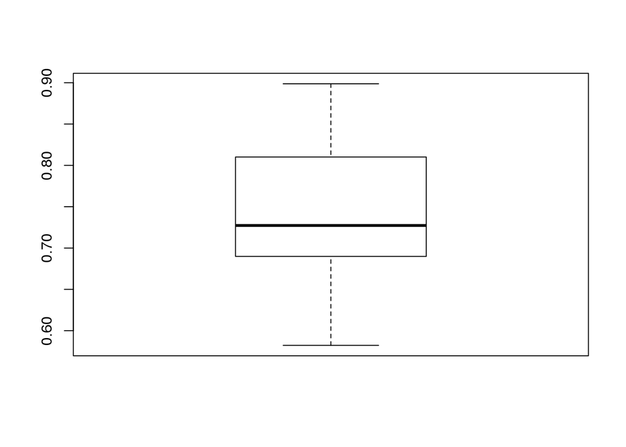

```r
boxplot(game$accuracy)
```

Second, it is possible to give a formula and a data frame. The formulas are given with tilde ~. The variable on the left of the tilde is the variable to be plotted, and the variable on the right is the grouping variable. This should be a factor (= nominal or ordered variable) when used with function boxplot. In practice, the function call says that “please make a boxplot of accuracy by age group, and look for the variables in given from the data frame given”.

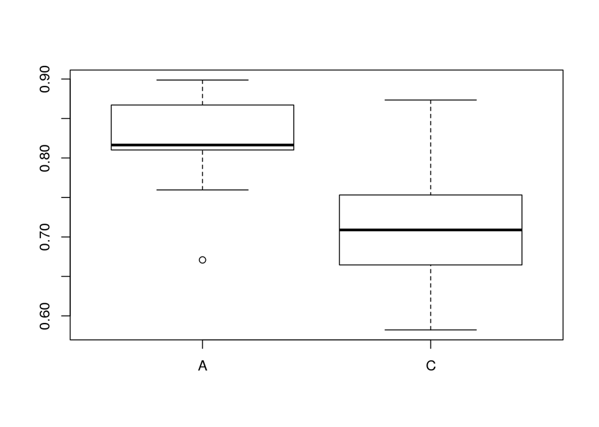

```r
boxplot(accuracy ~ age_grp, game)
```

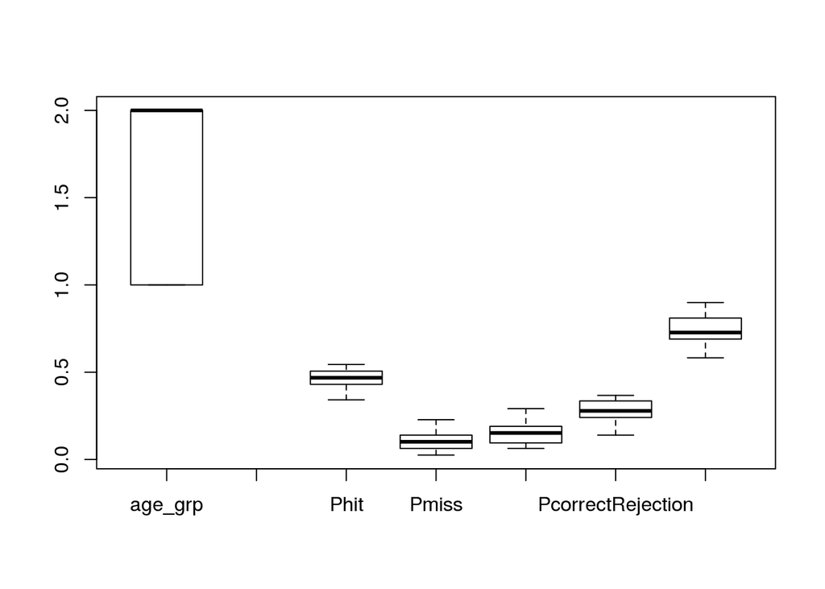

```r
boxplot(game)
```

## t-test

Using the formula notation, it is easy to make between groups t-test.

```r
t.test(accuracy ~ age_grp, game)
```

```
##
##  Welch Two Sample t-test
##
## data:  accuracy by age_grp
## t = 4.901, df = 23.536, p-value = 5.619e-05
## alternative hypothesis: true difference in means is not equal to 0
## 95 percent confidence interval:
##  0.06281851 0.15438208
## sample estimates:
## mean in group A mean in group C
##       0.8217300       0.7131297
```

Typically, it would just fine to copy the information from the output to an article manuscript. However, sometimes it would be useful to have a programmatic access to the results of a test. In R, it is possible, even quite easy. Look at the documentation of function t.test. Under heading Value, there are listed what components the return values contains. You can access these components with $.

```r
res <- t.test(accuracy ~ age_grp, game)

res$estimate # estimated means
```

```
## mean in group A mean in group C
##       0.8217300       0.7131297
```

```r
res$estimate[1] # this is actually a vector, even thought it contains the name
```

```
## mean in group A
##         0.82173
```

```r
res$estimate[2]
```

```
## mean in group C
##       0.7131297
```

```r
res$conf.int
```

```
## [1] 0.06281851 0.15438208
## attr(,"conf.level")
## [1] 0.95
```

```r
res$conf.int[1]
```

```
## [1] 0.06281851
```

```r
res$conf.int[2]
```

```
## [1] 0.1543821
```